# Task 1 Final

Augusto Fonseca, Paul Sharratt, Niklas Pawelzik, Justus v. Samson-Himmelstjerna

2022-12-20

```r
# load data
survey_df <- readRDS("../survey/meof_usa_survey_df.RDS")
time_zones_df <- readRDS("../time_zones/time_zones.RDS")
tracking_df <- readRDS("../tracking/meof_usa_web_df.RDS")
```

## Task 1.1 - Identifying respondents’ YouGov navigation during the survey interval

Author: Augusto Fonseca

The web-tracking data coincides with the fielding of the fourth wave of the survey. Provide a visualization following the best practices illustrating the breakdown of the three groups in the data:

• Survey respondents who visit “yougov” during the survey interval • Survey respondents who do not visit “yougov” during the survey interval • Participants who provided tracking data, but did not participate in the survey

The visualization should function as a standalone figure, explaining what it shows. Note that the survey is a combination of local times from the respondents’ locations, and that on November 4, 2018, Daylight Saving Time ended in the U.S.

RESOLUTION:

The question asks to identify respondents’ YouGov navigation during the survey interval. The survey data frame contains a start time variable and an end time variable. To define the “survey interval”, I will get the first start time (minimum start time) and the last end-time (maximum end time) among the respondents during the 4th survey wave.

Point of attention: The tracking data frame contains a variable that contains the time a person accessed a website in the UTC time zone. The time information presented in the survey data frame, on the other hand, is in local time. So, we need to convert it to the UTC timezone to allow any parsing.

```r
# upload data

survey_df_w4 <- filter(survey_df, wave == 4)

# Check the state and the time which the survey started.

survey_start_state <- as_factor(survey_df_w4 %>%
  select(starttime, inputstate) %>%
  filter(starttime == min(survey_df_w4$starttime)) %>%
  select(state = inputstate))

survey_end_state <- as_factor(survey_df_w4 %>%
  select(endtime, inputstate) %>%
  filter(endtime == max(survey_df_w4$endtime)) %>%
  select(state = inputstate))

survey_start_time <- min(survey_df_w4$starttime) #UTC timezone
survey_end_time <- max(survey_df_w4$endtime) #UTC timezone


# join timezone DF to get the timezone based on the State name
survey_start_state <- left_join(survey_start_state, time_zones_df, by = "state")
survey_end_state <- left_join(survey_end_state, time_zones_df, by = "state")

#Using the timezone, convert the start-time and the end-time to UTC timezone
survey_start_time <- with_tz(ymd_hms(survey_start_time, tz = survey_start_state$time_zone[1]), "UTC")
survey_end_time <- with_tz(ymd_hms(survey_end_time, tz = survey_end_state$time_zone[1]), "UTC")

# Considering that on November 4, 2018, Daylight Saving Time ended in the United States, just adjust the start time to disregard its effect.

survey_start_time <- survey_start_time - 3600 # Reduce 1 hour: 3600 seconds



# Joing data frames to filter the domains accessed during the survey interval
df_yougov <- left_join(tracking_df %>% filter (used_at >= survey_start_time & used_at <= survey_end_time), survey_df_w4 %>% select(personid, wave, inputstate), by = "personid")

#Fill NA in wave - For those who didn´t respond to the survey
df_yougov$wave[is.na(df_yougov$wave)] <- 0

# create a variable to check if the domain contains yougov
df_yougov2 <- df_yougov %>%
  add_column(yougov = str_detect(df_yougov$domain,'yougov'))

df_yougov2 <- df_yougov2 %>%
  mutate(
    respondents_class = case_when(
    ((wave == 4) & (yougov == TRUE)) ~ "Respondent and accessed Yougov",
    ((wave == 4) & (yougov == FALSE)) ~ "Respondent, but have not accessed Yougov",
    (wave == 0) ~ "Not respondent, but accessed Yougov")
    ) %>%
  mutate(
    class_number = case_when(
    ((wave == 4) &  (yougov == TRUE)) ~ 1,
    ((wave == 4) & (yougov == FALSE)) ~ 2,
    (wave == 0) ~ 3)
    )

# Create a DF to remove duplicates
df_yougov3 <- df_yougov2 %>%
  select(personid,class_number, respondents_class) %>%
  unique

# order by the class and remove duplicated entries
df_yougov3 <- df_yougov3[order(df_yougov3$personid, df_yougov3$class_number),]
df_yougov3 <- df_yougov3 %>% distinct(personid, .keep_all = TRUE)


df_yougov3 <- df_yougov3 %>%
  group_by(class_number, respondents_class) %>%
  summarise(num_ids = n())
```

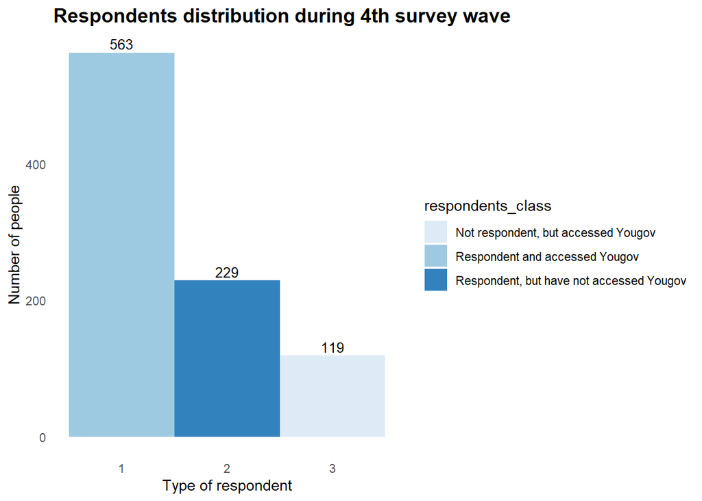

```r
# Bar plot with the share
plot1 <- ggplot(df_yougov3, aes(x=class_number, y=num_ids, fill=respondents_class)) +
  geom_bar(width = 1, stat = "identity")+
  geom_text(aes(label=num_ids), vjust=-0.3, size=3.5)+
  ggtitle("Respondents distribution during 4th survey wave")+
  xlab("Type of respondent") +
  ylab("Number of people")+
  scale_fill_brewer(palette="Blues")+
  theme_minimal()+
  theme(panel.border = element_blank(),
        panel.grid=element_blank(),
        axis.ticks = element_blank(),
        plot.title=element_text(size=14, face="bold"))
print(plot1)
```

## Task 1.2 - Writing a function to explore the distribution of answers for a given question on each of the survey waves

Author: Paul Sharratt

Writing a function to explore the distribution of answers for a given question on each of the survey waves

Write a function to illustrate the distribution of answers for a given discrete choice question (not: questions with open text) on each of the survey waves. The function should:

• take the data frame and survey item as arguments. • return a small multiple barplot grouped at the survey wave-level with the answer option counts (including NAs). • present the original survey question (label) and the variable name in the title of the plot. • graph the value labels in the answer tick axis (i.e., in presvote16post, you would want “Hillary Clinton”,“Donald Trump”, etc., rather than the numbers representing these values) • stop if the input variable is not a labelled <dbl+lbl> type.

Prove the correct behavior of the function with at least three survey questions.

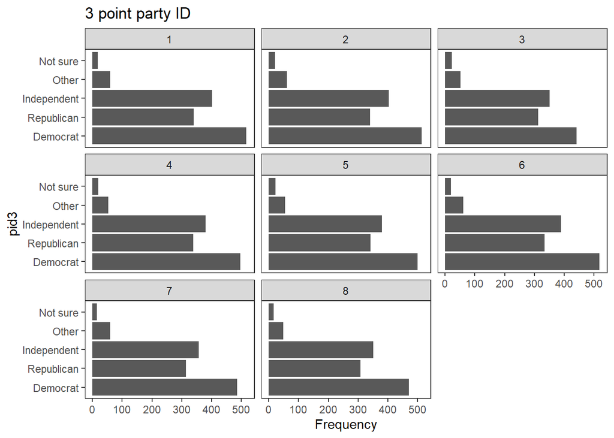

```r
distribution_function <- function(data, item){
  item_qs <- deparse(substitute(item))  # assigning item as a quoted object

if (sum(class(data%>%pull(item_qs)) %in% c("haven_labelled", "vctrs_vctr", "double" )) == 3 )
  # checking if item_qs is <dbl+lbl> by checking class labels, can't use str() and indexing
  {
    data[[item_qs]] <- haven::as_factor(data[[item_qs]]) # using haven as_factor function
    ggplot(data,     # creating a small multiples plot
           aes(x = {{item}})) + # passing unquoted variables using {{}}
      geom_bar() +
      scale_x_discrete() +
      theme_test() +
      coord_flip() +
      labs(title = strwrap(paste0(attributes(survey_df[[item_qs]])$label)), # using 'label' from item_qs attributes for title
       x = item_qs,
       y = "Frequency") +
      facet_wrap(~wave, nrow = 3)
    } else {
      stop("The input variable is not a labelled <dbl+lbl> type.")
      }
}

# testing the function
distribution_function(survey_df, pid3)
```

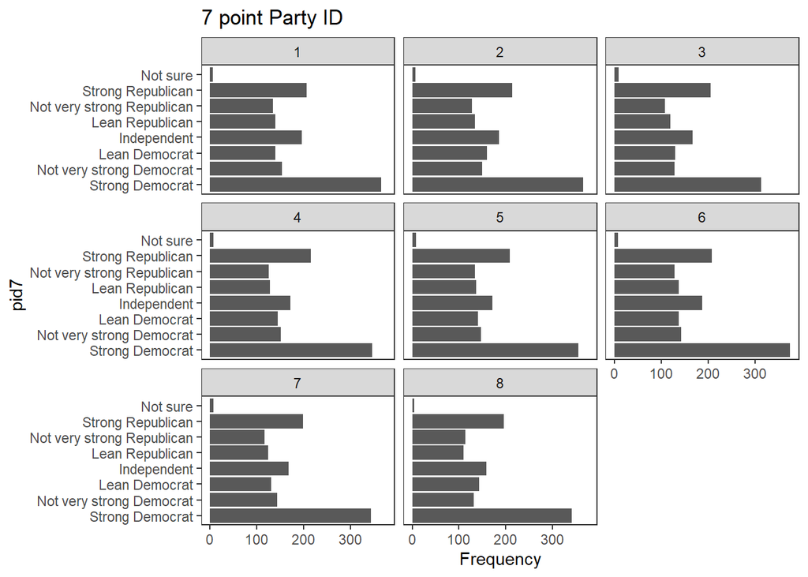

```r
distribution_function(survey_df, pid7)
```

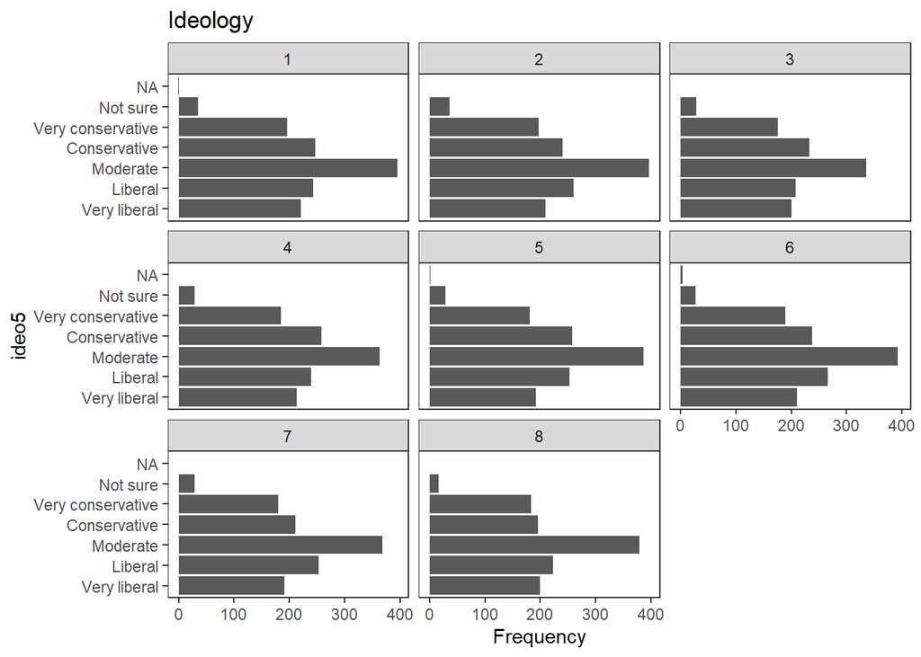

```r
distribution_function(survey_df, ideo5)
```

```r
# Note: almost certain there's a way to make this work with sjlabelle package, but couldn't get it to work.
```

## Task 1.3 - Distribution of Netflix activity throughout the day by the weekday

Author: Niklas Pawelzik

Illustrate with a ridgeplot the distribution of Netflix activity throughout the day by weekday following good practice of visualizations. For this plot you should:

• match each respondent with their first logged state of residence in the survey. • update the time of each web activity based on the user’s home state and the respective time zone in times_zones.RDS. • add vertical lines at the quartiles. • provide a title and description, making it a standalone figure that speaks for itself.

```r
survey_df$inputstate <-
  case_when(survey_df$inputstate == 1 ~ "Alabama",
            survey_df$inputstate == 2 ~ "Alaska",
            survey_df$inputstate == 4 ~ "Arizona",
            survey_df$inputstate == 5 ~ "Arkansas",
            survey_df$inputstate == 6 ~ "California",
            survey_df$inputstate == 8 ~ "Colorado",
            survey_df$inputstate == 9 ~ "Connecticut",
            survey_df$inputstate == 10 ~ "Delaware",
            survey_df$inputstate == 11 ~ "District of Columbia",
            survey_df$inputstate == 12 ~ "Florida",
            survey_df$inputstate == 13 ~ "Georgia",
            survey_df$inputstate == 15 ~ "Hawaii",
            survey_df$inputstate == 16 ~ "Idaho",
            survey_df$inputstate == 17 ~ "Illinois",
            survey_df$inputstate == 18 ~ "Indiana",
            survey_df$inputstate == 19 ~ "Iowa",
            survey_df$inputstate == 20 ~ "Kansas",
            survey_df$inputstate == 21 ~ "Kentucky",
            survey_df$inputstate == 22 ~ "Louisiana",
            survey_df$inputstate == 23 ~ "Maine",
            survey_df$inputstate == 24 ~ "Maryland",
            survey_df$inputstate == 25 ~ "Massachusetts",
            survey_df$inputstate == 26 ~ "Michigan",
            survey_df$inputstate == 27 ~ "Minnesota",
            survey_df$inputstate == 28 ~ "Mississippi",
            survey_df$inputstate == 29 ~ "Missouri",
            survey_df$inputstate == 30 ~ "Montana",
            survey_df$inputstate == 31 ~ "Nebraska",
            survey_df$inputstate == 32 ~ "Nevada",
            survey_df$inputstate == 33 ~ "New Hampshire",
            survey_df$inputstate == 34 ~ "New Jersey",
            survey_df$inputstate == 35 ~ "New Mexico",
            survey_df$inputstate == 36 ~ "New York",
            survey_df$inputstate == 37 ~ "North Carolina",
            survey_df$inputstate == 38 ~ "North Dakota",
            survey_df$inputstate == 39 ~ "Ohio",
            survey_df$inputstate == 40 ~ "Oklahoma",
            survey_df$inputstate == 41 ~ "Oregon",
            survey_df$inputstate == 42 ~ "Pennsylvania",
            survey_df$inputstate == 44 ~ "Rhode Island",
            survey_df$inputstate == 45 ~ "South Carolina",
            survey_df$inputstate == 46 ~ "South Dakota",
            survey_df$inputstate == 47 ~ "Tennessee",
            survey_df$inputstate == 48 ~ "Texas",
            survey_df$inputstate == 49 ~ "Utah",
            survey_df$inputstate == 50 ~ "Vermont",
            survey_df$inputstate == 51 ~ "Virginia",
            survey_df$inputstate == 53 ~ "Washington",
            survey_df$inputstate == 54 ~ "West Virginia",
            survey_df$inputstate == 55 ~ "Wisconsin",
            survey_df$inputstate == 56 ~ "Wyoming",
            survey_df$inputstate == 60 ~ "American Samoa",
            survey_df$inputstate == 64 ~ "Federated States of Micronesia",
            survey_df$inputstate == 66 ~ "Guam",
            survey_df$inputstate == 68 ~ "Marshall Islands",
            survey_df$inputstate == 69 ~ "Northern Mariana Islands",
            survey_df$inputstate == 70 ~ "Palau",
            survey_df$inputstate == 72 ~ "Puerto Rico",
            survey_df$inputstate == 74 ~ "U.S. Minor Outlying Islands",
            survey_df$inputstate == 78 ~ "Virgin Islands",
            survey_df$inputstate == 81 ~ "Alberta",
            survey_df$inputstate == 82 ~ "British Columbia",
            survey_df$inputstate == 83 ~ "Manitoba",
            survey_df$inputstate == 84 ~ "New Brunswick",
            survey_df$inputstate == 85 ~ "Newfoundland",
            survey_df$inputstate == 86 ~ "Northwest Territories",
            survey_df$inputstate == 87 ~ "Nova Scotia",
            survey_df$inputstate == 88 ~ "Nunavut",
            survey_df$inputstate == 89 ~ "Ontario",
            survey_df$inputstate == 90 ~ "Prince Edward Island",
            survey_df$inputstate == 91 ~ "Quebec",
            survey_df$inputstate == 92 ~ "Saskatchewan",
            survey_df$inputstate == 93 ~ "Yukon Territory")
```

```r
# identify first logged state of residence in the survey
## filter for one match per "personid", displaying the lowest number of "wave" for which we have a value in "inputstate"
earliest_inputstate <- survey_df %>%
  filter(!is.na(inputstate))%>%
  group_by(personid)%>%
  arrange(wave) %>%
  slice(1) %>%
  ungroup() %>%
  select(personid, inputstate)

# update the time of each web activity based on the user‘s home state and the respective time zone in times_zones.RDS

earliest_inputstate <- earliest_inputstate %>%
    rename("state" = "inputstate")

earliest_inputstate <- merge(x=earliest_inputstate, y=time_zones_df, by= "state", all.x=TRUE)
```

```r
# search for netflix use and create data frame
netflix_use <- tracking_df[tracking_df$domain=='netflix' | grepl('netflix',tracking_df$domain), ]

netflix_use <- merge(x=netflix_use, y=earliest_inputstate, by= "personid", all.x=TRUE)
```

```r
# set duration to "second" instead of minutes
netflix_use$duration <- netflix_use$duration * 60
# create end_date column
netflix_use$stopped_use_at <- netflix_use$used_at + netflix_use$duration
# create weekday column
netflix_use$weekday_used <- weekdays(netflix_use$used_at)

# rename weekdays
netflix_use$weekday_used[netflix_use$weekday_used == 'Montag'] <- 'Monday'
netflix_use$weekday_used[netflix_use$weekday_used == 'Dienstag'] <- 'Tuesday'
netflix_use$weekday_used[netflix_use$weekday_used == 'Mittwoch'] <- 'Wednesday'
netflix_use$weekday_used[netflix_use$weekday_used == 'Donnerstag'] <- 'Thursday'
netflix_use$weekday_used[netflix_use$weekday_used == 'Freitag'] <- 'Friday'
netflix_use$weekday_used[netflix_use$weekday_used == 'Samstag'] <- 'Saturday'
netflix_use$weekday_used[netflix_use$weekday_used == 'Sonntag'] <- 'Sunday'

# isolate_day_time_hour
netflix_use$hour_used <- hour(netflix_use$used_at)

# isolate_day_time_minute
netflix_use$minute_used <- minute(netflix_use$used_at)

# isolate_day_time_second
netflix_use$second_used <- second(netflix_use$used_at)

netflix_use$day_time_used <- hms(paste(netflix_use$hour_used, netflix_use$minute_used, netflix_use$second_used, sep = ":"))

netflix_use$day_time_used_2 <- hms::as_hms(netflix_use$used_at)

netflix_use$day_time_used_local_time_2 <- hms::as_hms(netflix_use$used_at_local_time)
```

```r
# change UTC to state time zones
# (Credit to fellow-student Armin, function comes from him):
local_time <- Vectorize(function(x,y){format(x, tz=y, usetz=TRUE)})

netflix_use <- netflix_use %>%
  mutate(
    used_at_local_time = map2(.x = used_at, .y = time_zone, .f = local_time)
  )

netflix_use <- netflix_use %>%
  unnest(used_at_local_time)

netflix_use$used_at_local_time <- as.POSIXct(netflix_use$used_at_local_time, format = "%Y-%m-%d %H:%M:%S")
```